# Traitement des données | Nettoyage

Clément Borel

24 janvier 2022

## Nettoyage des données

Nous traiterons, dans ce document, des méthodes de nettoyage de données tabulaires avec Google Spreadsheet. Le choix de cet outil est motivé par son accessibilité quelque soit l’OS.

### Rappel de la méthodologie

Lorsque vous travaillé sur des données, veillez à respecter cette méthodologie qui permettra de structuré et documenter votre travail, afin de le rendre plus compréhensible et plus facilement partageable ; mais aussi retrouver facilement les informations initiales en cas d’erreur ou de mauvaise manipulation des données.

1. Importez les données de base dans une première feuille de calcul; appelez-la **source**. Vous pouvez également adjoindre un nom pertinent qui rappelle la thématique des données. *Ex : “source - villes françaises”* Vous ne toucherez plus cette feuille, elle sert de sauvegarde et contient les données brutes, non traitées.
2. Dupliquez cette feuille et nommez-la **travail** ; c’est dans cette feuille que vous effectuerez les traitements sur vos données.
3. Créez une troisième feuille de calcul **“metadata”** ; dans cette feuille marquez (au moins) le nom de la source, l’URL de la source (ou la référence biblio), la date de téléchargement ou consultation ; ajoutez toutes entrées qui vous semblent pertinentes pour la documentation de votre travail.

### Identifier les problèmes…

Il est parfois difficile d’identifier les problèmes dans les jeux de données surtout lorsque ceux-ci sont volumineux. Une bonne pratique consiste à **trier les plages** de données. Ce tri vous fournit une liste exhaustive des valeurs uniques contenu dans une colonne. Il est ainsi plus aisé de repérer les valeurs manquantes ou encore les doublons mal écrit.

### …et les résoudre

#### Les types de données

Assurez-vous que le tableur considère les données à leur juste type ; autrement dit, qu’un nombre est bien considéré comme un nombre, une date comme une date, une chaîne de caractères comme une chaîne de caractères, etc.

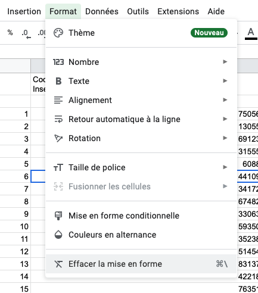

Capture d’écran 2022-01-24 à 14.42.16.png

Pour s’assurer du type des données d’une colonne, sélectionnez la colonne (cliquez sur la l’entête lettrée) et choisissez le format de données adéquat dans la barre d’outils :

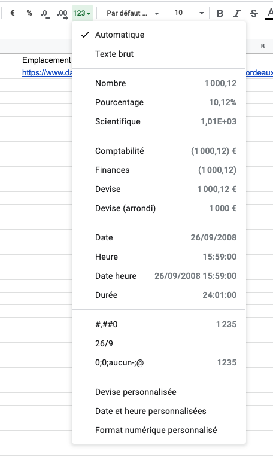

FormatDonnees.png

### Rechercher / remplacer

Votre meilleur ami dans le traitement par lot de grands jeux de données est l’outil “Rechercher/remplacer”. Il permet de remplacer toutes les occurrences d’une chaîne de caractères par une autre chaîne ou une chaîne vide (rien donc).

Très utile pour : * supprimer certains caractères non désirés * transformer en virgules **,** les points **.** dans les notations anglaises des nombres décimaux * transformer les erreurs d’encodage des caractères (notamment sur les lettres accentuées et les caractères spéciaux) * …

Pour ce faire, sélectionnez la plage de données sur laquelle appliquer la recherche. Puis choississez *Edition > Rechercher et remplacer* (ou CTRL+MAJ+H). Entrez la chaîne recherchée et la chaîne de remplacement ; laissez vide la seconde pour effacer la chaîne recherchée. Cliquez sur *Tout remplacer*.

**Astuce :** Vous pouvez vérifier la validité de votre recherche en cliquant sur *Rechercher* avant de tout remplacer. Utilisez les options cliquables pour encore plus finesse.

### Quelques formules de calcul utiles

**=MIN(*valeurs*)** : renvoie la plus petite valeur d’un ensemble de valeurs. **=MAX(*valeurs*)** : renvoie la plus grande valeur d’un ensemble de valeurs.

**=SUM(*valeurs*)** : renvoie la somme d’un ensemble de valeurs. **=AVERAGE(*valeurs*)** : renvoie la moyenne d’un ensemble de valeurs. **=STDEV(*valeurs*)** : renvoie l’écart type d’un ensemble de valeurs

**=COUNT(*valeurs*)** : renvoie le nombre de valeurs **numériques** d’un ensemble de données. **=COUNTA(*valeurs*)** : renvoie le nombre de valeurs d’un ensemble de données. **=COUNTIF(*plage*;*critère*)** : renvoie le nombre de valeurs correspondant au critère.

### D’autres formules utiles

**=CONCATENATE(*plage*)** : concatène (joint bout à bout) les valeurs de la plage **=JOINT(“*délimiteur*”;*plage*)** : joint, séparé par le délimiteur, les valeurs de la plage **=SPLIT(“*délimiteur*”;*valeur*)** : sépare (dans des cellules séparées) un texte selon un délimiteur **=UNIQUE(*plage*)** : Renvoie les valeur (par ligne) de la plage source fournie, en excluant les doublons. **=LEFT(*valeur*;*n*)** : renvoie les *n* premiers caractères d’une valeur **=RIGHT(*valeur*;*n*)** : renvoie les *n* derniers caractères d’une valeur

**Astuce** : Quand vous avez fait certaines opérations, il peut être intéressant de ne plus considérer ces cellules comme des **formules**, mais de les transformer en **valeurs**. Pensez alors à l’option **“coller uniquement les valeurs”** (ou **CTRL+MAJ+V**).

## Trouver des données

### Les données ouvertes

Une bonne source pour trouver des données est de parcourir les portails open de données ouvertes (open data). Voici une liste non exhaustive de portails francophones que vous pouvez utiliser : - data.gouv.fr - https://data.culture.gouv.fr/pages/home/ - https://www.insee.fr/fr/accueil - https://ressources.data.sncf.com/pages/accueil/ - [Datainfogreffe.fr](https://www.axysweb.com/top-15-des-sources-open-data/#datainfogreffe.fr) - [Donnees.banquemondiale.org](https://www.axysweb.com/top-15-des-sources-open-data/#banquemondiale) - [Data.inpi.fr](https://www.axysweb.com/top-15-des-sources-open-data/#data.inpi.fr) - [Data.economie.gouv.fr](https://www.axysweb.com/top-15-des-sources-open-data/#data.economie.gouv.fr) - [Pole-emploi.io](https://www.axysweb.com/top-15-des-sources-open-data/#pole-emploi.io) - [Adresse.data.gouv.fr](https://www.axysweb.com/top-15-des-sources-open-data/#adresse.data.gouv.fr) - [Data.education.gouv.fr](https://www.axysweb.com/top-15-des-sources-open-data/#data.education.gouv.fr) - [Datatourisme.gouv.fr](https://www.axysweb.com/top-15-des-sources-open-data/#datatourisme.gouv.fr) - [Donnéespubliques.meteofrance.fr](https://www.axysweb.com/top-15-des-sources-open-data/#donn%C3%A9espubliques.meteofrance.fr) - [Base-données-publiques.médicaments.gouv.fr](https://www.axysweb.com/top-15-des-sources-open-data/#base-donn%C3%A9es-publiques.m%C3%A9dicaments.gouv.fr) - Pour en découvrir davantage : http://dataportals.org/ ou entrez dans votre moteur de recherche favori une thématique, une institution, un territoire adjoint du terme “Open Data” est laissez-vous guider ;)

### Le Web scrapping

Les pages web sont elles-mêmes des sources potentielles de données. Le langage HTML qui régit ces pages étant un langage structuré, il est relativement simple d’extraire de façon automatique (ou presque) des données sous une forme exploitable. Pour ceux qui souhaitent tenter l’expérience, voici une liste non exhaustive d’outils de *“web scrapping”* : - https://www.import.io/ - https://scrapy.org/ - https://webhose.io/ - http://webscraper.io/ - https://phantombuster.com/ - https://apify.com/ - https://www.scraping-bot.io/ - https://www.parsehub.com/ - https://www.parsehub.com/ - https://www.octoparse.com/

Plus simple, la fonction **IMPORTHTML** de Google Sheet qui permet de récupérer directement du contenu tabulaire de wikipedia ; autrement dit extraire un tableau d’une page Wikipedia. Comment ca marche ? 1. Allez sur la page wikipedia sur laquelle se trouve le tableau ; copiez l’URL 2. Repérez l’occurrence (position) du tableau à extraire (nième tableau de la page) 3. Dans une feuille de calcul vierge, tapez : =IMPORTHTML(“*URL*”;“table”;*occurrence*)

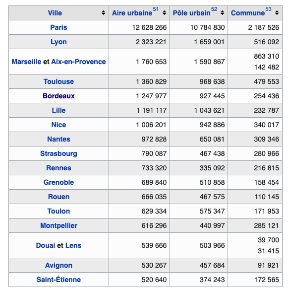

Capture d’écran 2022-01-24 à 15.34.05.png

J’entre donc : =IMPORTHTML(“https://fr.wikipedia.org/wiki/France”;“table”;9). Bingo :

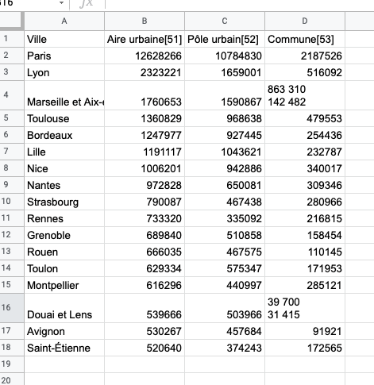